# Step 3: Post-process monkey study-design results

Author

NAMLink

# Purpose and analysis

This script calculates dense and sparse individual PK endpoints from the Step 2 checkpoints, then compares each sparse reduced-study estimate directly with the dense population truth from the same parameter-draw replicate, molecule, variability level, and dose.

Dense truth is the arithmetic mean of the evaluable individual dense endpoints in the matched cell, normally all 50 monkeys. A profile that still has no concentration-time output after the Step 2 batch and single-profile retries is excluded only from its exact molecule-by-CV-by-replicate-by-dose cell. Its other doses remain eligible. Sparse studies select 2, 3, or 6 distinct evaluable monkeys without replacement within each dose group. Selection is independent between dose groups, so a monkey may be reused at a different dose. The selected monkey set is shared by all three endpoints and by candidate designs containing the same dose.

The replicate-matched comparison remains the primary study-design metric. A separate secondary analysis compares the same sparse-study estimates with the fixed nominal typical-subject reference simulated in Step 2. This secondary comparison describes total deviation from the prior nominal prediction and is reported separately so parameter uncertainty is not mislabeled as design error.

```r
rm(list = ls())

suppressPackageStartupMessages({
  library(dplyr)
  library(ggplot2)
  library(knitr)
  library(purrr)
  library(readr)
  library(scales)
  library(tibble)
  library(tidyr)
})

find_project_root <- function(start = getwd()) {
  current <- normalizePath(start, winslash = "/", mustWork = TRUE)
  repeat {
    required <- c(
      file.path(current, "00_Data"),
      file.path(current, "01_Models"),
      file.path(current, "02_APriori_PBPK_Workflow"),
      file.path(current, "03_Study_Simulations")
    )
    if (all(dir.exists(required))) return(current)
    parent <- dirname(current)
    if (identical(parent, current)) {
      stop("Could not locate the PBPK_mAb_NAM_Tutorial project root.")
    }
    current <- parent
  }
}

assert_files_exist <- function(paths, description = "Required input") {
  missing <- paths[!file.exists(paths)]
  if (length(missing) > 0L) {
    stop(description, " is missing: ", paste(missing, collapse = "; "))
  }
  invisible(paths)
}

atomic_save_rds <- function(object, path) {
  temporary_path <- tempfile(
    pattern = "study_design_endpoint_checkpoint_",
    tmpdir = dirname(path),
    fileext = ".rds"
  )
  saveRDS(object, temporary_path, compress = "xz")
  copied <- file.copy(temporary_path, path, overwrite = TRUE)
  unlink(temporary_path)
  if (!copied) stop("Could not save endpoint checkpoint: ", path)
  invisible(path)
}

PROJECT_ROOT <- find_project_root()
STUDY_DIR <- file.path(PROJECT_ROOT, "03_Study_Simulations")
STEP1_RDS <- file.path(
  STUDY_DIR, "SimsOutputs", "Step1_Inputs", "Objects",
  "study_design_step1_inputs.rds"
)
STEP2_INDEX_RDS <- file.path(
  STUDY_DIR, "SimsOutputs", "Step2_Simulations", "Objects",
  "study_design_step2_run_index.rds"
)

OUTPUT_DIR <- file.path(STUDY_DIR, "SimsOutputs", "Step3_Results")
CHECKPOINT_DIR <- file.path(OUTPUT_DIR, "EndpointCheckpoints")
TABLE_DIR <- file.path(OUTPUT_DIR, "Tables")
FIGURE_DIR <- file.path(OUTPUT_DIR, "Figures")
OBJECT_DIR <- file.path(OUTPUT_DIR, "Objects")
walk(
  c(OUTPUT_DIR, CHECKPOINT_DIR, TABLE_DIR, FIGURE_DIR, OBJECT_DIR),
  dir.create,
  recursive = TRUE,
  showWarnings = FALSE
)

INDIVIDUAL_ENDPOINT_FILE <- file.path(
  TABLE_DIR, "study_design_individual_dense_sparse_endpoints.csv"
)
POPULATION_TRUTH_FILE <- file.path(
  TABLE_DIR, "study_design_replicate_matched_dense_truth.csv"
)
SAMPLING_ASSIGNMENT_FILE <- file.path(
  TABLE_DIR, "study_design_sparse_sampling_assignments.csv"
)
FOLD_ERROR_REPLICATE_FILE <- file.path(
  TABLE_DIR, "study_design_replicate_matched_fold_error.csv"
)
FOLD_ERROR_SUMMARY_FILE <- file.path(
  TABLE_DIR, "study_design_fold_error_summary.csv"
)
NOMINAL_REFERENCE_ENDPOINT_FILE <- file.path(
  TABLE_DIR, "study_design_nominal_typical_reference_endpoints.csv"
)
NOMINAL_FOLD_ERROR_REPLICATE_FILE <- file.path(
  TABLE_DIR, "study_design_nominal_typical_fold_error.csv"
)
NOMINAL_FOLD_ERROR_SUMMARY_FILE <- file.path(
  TABLE_DIR, "study_design_nominal_typical_fold_error_summary.csv"
)
ENDPOINT_SUCCESS_FILE <- file.path(
  TABLE_DIR, "study_design_endpoint_success.csv"
)
OVERALL_SUCCESS_FILE <- file.path(
  TABLE_DIR, "study_design_overall_success.csv"
)
ANALYSIS_QC_FILE <- file.path(
  TABLE_DIR, "study_design_analysis_qc.csv"
)
FAILED_PROFILE_EXCLUSION_FILE <- file.path(
  TABLE_DIR, "study_design_excluded_failed_profiles.csv"
)
ENDPOINT_CHECKPOINT_INVENTORY_FILE <- file.path(
  TABLE_DIR, "study_design_endpoint_checkpoint_inventory.csv"
)
SETTINGS_FILE <- file.path(
  TABLE_DIR, "study_design_step3_settings.csv"
)
PACKAGE_FILE <- file.path(
  TABLE_DIR, "study_design_step3_software_versions.csv"
)
ARTIFACT_MANIFEST_FILE <- file.path(
  TABLE_DIR, "study_design_step3_artifact_manifest.csv"
)
RESULTS_RDS <- file.path(
  OBJECT_DIR, "study_design_step3_results.rds"
)
FOLD_ERROR_FIGURE <- file.path(
  FIGURE_DIR, "study_design_replicate_matched_fold_error.png"
)
NOMINAL_FOLD_ERROR_FIGURE <- file.path(
  FIGURE_DIR, "study_design_nominal_typical_fold_error.png"
)

FORCE_RERUN <- tolower(Sys.getenv(
  "STUDY_DESIGN_FORCE_POSTPROCESS",
  unset = "false"
)) %in% c("true", "1", "yes")
SAMPLING_SEED_BASE <- 20262919L
FOLD_LIMITS <- c(0.5, 2)
ENDPOINT_LEVELS <- c("AUC0-28d", "Cmax", "Terminal clearance")

assert_files_exist(c(STEP1_RDS, STEP2_INDEX_RDS), "Step 3 input")
step1 <- readRDS(STEP1_RDS)
step2 <- readRDS(STEP2_INDEX_RDS)
settings <- step1$settings
STEP1_INPUT_MD5 <- unname(tools::md5sum(STEP1_RDS))

if (!identical(step2$step1_input_md5, STEP1_INPUT_MD5)) {
  stop("Step 1 changed after Step 2. Rerender Step 2 before Step 3.")
}
if (is.null(step2$nominal_reference_file) ||
    is.null(step2$nominal_reference_md5)) {
  stop("Step 2 does not contain the nominal typical-subject reference.")
}
assert_files_exist(
  step2$nominal_reference_file,
  "Step 2 nominal typical-subject reference"
)
if (!identical(
  unname(tools::md5sum(step2$nominal_reference_file)),
  step2$nominal_reference_md5
)) {
  stop("The Step 2 nominal reference checksum changed.")
}
nominal_reference <- readRDS(step2$nominal_reference_file)
if (!is.list(nominal_reference) ||
    !identical(nominal_reference$format_version, 1L) ||
    !identical(nominal_reference$step1_input_md5, STEP1_INPUT_MD5) ||
    !is.data.frame(nominal_reference$profiles)) {
  stop("The Step 2 nominal reference is incomplete or incompatible.")
}
if (!is.numeric(settings$n_replicates) || settings$n_replicates < 1L ||
    !is.numeric(settings$n_population_animals) ||
      settings$n_population_animals < max(settings$animals_per_group)) {
  stop("The Step 1 record does not contain a valid approved analysis size.")
}

required_failure_columns <- c(
  "Timestamp", "Molecule", "Variability_CV", "Dose_mg_kg", "BatchId",
  "Replicate", "PopulationIndividualId", "TruthProfileId", "Error"
)
failed_profiles <- as_tibble(step2$failed_profiles)
if (!all(required_failure_columns %in% names(failed_profiles))) {
  stop("The Step 2 failed-profile record does not have the expected schema.")
}
recorded_failure_count <- sum(
  as.integer(step2$checkpoint_inventory$Failed_profiles)
)
failure_key_columns <- c(
  "Molecule", "Variability_CV", "Replicate", "Dose_mg_kg",
  "TruthProfileId"
)
if (nrow(failed_profiles) != recorded_failure_count ||
    anyDuplicated(failed_profiles[failure_key_columns]) > 0L ||
    any(!failed_profiles$Dose_mg_kg %in% settings$doses_mg_kg)) {
  stop("The Step 2 failed-profile record is inconsistent with its inventory.")
}

profile_index_for_failures <- step1$crossed_profile_index |>
  select(
    .data$Molecule,
    .data$Variability_CV,
    .data$Replicate,
    .data$PopulationIndividualId,
    .data$TruthProfileId,
    .data$Monkey_index
  )
failed_profile_exclusions <- failed_profiles |>
  left_join(
    profile_index_for_failures,
    by = c(
      "Molecule", "Variability_CV", "Replicate",
      "PopulationIndividualId", "TruthProfileId"
    ),
    relationship = "many-to-one"
  )
if (nrow(failed_profile_exclusions) > 0L &&
    anyNA(failed_profile_exclusions$Monkey_index)) {
  stop("A Step 2 failed profile does not match the Step 1 profile index.")
}

failed_profile_cells <- failed_profile_exclusions |>
  count(
    .data$Molecule,
    .data$Variability_CV,
    .data$Replicate,
    .data$Dose_mg_kg,
    name = "Excluded_profiles"
  )
expected_truth_counts <- expand_grid(
  Molecule = settings$molecules,
  Variability_CV = settings$variability_cv,
  Replicate = seq_len(settings$n_replicates),
  Dose_mg_kg = settings$doses_mg_kg
) |>
  left_join(
    failed_profile_cells,
    by = c("Molecule", "Variability_CV", "Replicate", "Dose_mg_kg")
  ) |>
  mutate(
    Excluded_profiles = replace_na(.data$Excluded_profiles, 0L),
    Expected_monkeys_in_truth =
      settings$n_population_animals - .data$Excluded_profiles
  )
if (any(expected_truth_counts$Expected_monkeys_in_truth <
        max(settings$animals_per_group))) {
  stop("A failed-profile exclusion leaves too few monkeys for a sparse group.")
}

failed_profile_exclusions <- failed_profile_exclusions |>
  left_join(
    expected_truth_counts |>
      select(
        .data$Molecule,
        .data$Variability_CV,
        .data$Replicate,
        .data$Dose_mg_kg,
        Dense_truth_monkeys_after_exclusion =
          .data$Expected_monkeys_in_truth
      ),
    by = c("Molecule", "Variability_CV", "Replicate", "Dose_mg_kg"),
    relationship = "many-to-one"
  ) |>
  mutate(
    Exclusion_rule = paste(
      "No concentration-time output after Step 2 batch and",
      "single-profile retries"
    ),
    Analysis_action = paste(
      "Excluded only from matched dense truth and sparse sampling",
      "at this dose; other doses retained"
    )
  )
write_csv(failed_profile_exclusions, FAILED_PROFILE_EXCLUSION_FILE)

if (nrow(failed_profile_exclusions) > 0L) {
  message(
    "Step 3 will exclude ", nrow(failed_profile_exclusions),
    " failed Step 2 profile(s) from their matched dose cells."
  )
  failed_profile_exclusions |>
    select(
      .data$Molecule,
      `Variability CV (%)` = .data$Variability_CV,
      .data$Replicate,
      `Dose (mg/kg)` = .data$Dose_mg_kg,
      .data$Monkey_index,
      .data$TruthProfileId,
      .data$Dense_truth_monkeys_after_exclusion,
      .data$Error,
      .data$Analysis_action
    ) |>
    mutate(`Variability CV (%)` = 100 * `Variability CV (%)`) |>
    kable(caption = "Explicit Step 2 profile exclusions used in Step 3")
} else {
  tibble(Status = "No Step 2 profile exclusions") |>
    kable(caption = "Step 3 failed-profile exclusion status")
}
```

Explicit Step 2 profile exclusions used in Step 3

| Molecule | Variability CV (%) | Replicate | Dose (mg/kg) | Monkey_index | TruthProfileId | Dense_truth_monkeys_after_exclusion | Error | Analysis_action |
| --- | --- | --- | --- | --- | --- | --- | --- | --- |
| Golimumab | 30 | 16 | 3 | 13 | Golimumab_cv30_rep016_monkey13 | 49 | `.main()`: no results exist for path “Organism\|PeripheralVenousBlood\|mAb\|Plasma (Peripheral Venous Blood)” for individual ID ! | Excluded only from matched dense truth and sparse sampling at this dose; other doses retained |
| Golimumab | 60 | 39 | 3 | 13 | Golimumab_cv60_rep039_monkey13 | 49 | `.main()`: no results exist for path “Organism\|PeripheralVenousBlood\|mAb\|Plasma (Peripheral Venous Blood)” for individual ID ! | Excluded only from matched dense truth and sparse sampling at this dose; other doses retained |

```r
package_record <- tibble(
  Package = c(
    "R", "dplyr", "ggplot2", "knitr", "purrr",
    "readr", "scales", "tibble", "tidyr"
  ),
  Version = c(
    paste(R.version$major, R.version$minor, sep = "."),
    map_chr(
      c(
        "dplyr", "ggplot2", "knitr", "purrr",
        "readr", "scales", "tibble", "tidyr"
      ),
      ~ as.character(packageVersion(.x))
    )
  )
)
write_csv(package_record, PACKAGE_FILE)
```

# Step 1 Define the endpoint calculations

The functions reproduce the prior workflow: linear-up/log-down trapezoidal AUC, maximum observed concentration, and terminal clearance calculated from `AUCinf = AUClast + Clast/lambda_z`. When time zero is absent, the first sampled concentration is carried back to time zero, matching the earlier analysis.

```r
linup_logdown_auc <- function(time_h, concentration) {
  profile <- tibble(
    time_h = as.numeric(time_h),
    concentration = as.numeric(concentration)
  ) |>
    filter(
      is.finite(.data$time_h),
      is.finite(.data$concentration),
      .data$time_h >= 0,
      .data$time_h <= settings$auc_end_h,
      .data$concentration >= 0
    ) |>
    group_by(.data$time_h) |>
    summarise(concentration = mean(.data$concentration), .groups = "drop") |>
    arrange(.data$time_h)

  if (nrow(profile) < 2L) return(NA_real_)
  if (!any(profile$time_h == 0)) {
    profile <- bind_rows(
      tibble(time_h = 0, concentration = first(profile$concentration)),
      profile
    ) |>
      arrange(.data$time_h)
  }

  dt <- diff(profile$time_h)
  c1 <- head(profile$concentration, -1)
  c2 <- tail(profile$concentration, -1)
  declining <- c2 < c1 & c1 > 0 & c2 > 0
  intervals <- dt * (c1 + c2) / 2
  intervals[declining] <-
    dt[declining] * (c1[declining] - c2[declining]) /
    log(c1[declining] / c2[declining])
  sum(intervals)
}

best_terminal_lambda_z <- function(time_h, concentration, min_points = 3L) {
  terminal_data <- tibble(
    time_h = as.numeric(time_h),
    concentration = as.numeric(concentration)
  ) |>
    filter(
      is.finite(.data$time_h),
      is.finite(.data$concentration),
      .data$concentration > 0
    ) |>
    group_by(.data$time_h) |>
    summarise(concentration = mean(.data$concentration), .groups = "drop") |>
    arrange(.data$time_h)

  if (nrow(terminal_data) < min_points) return(NA_real_)
  tmax_index <- which.max(terminal_data$concentration)[1]
  start_index <- min(tmax_index + 1L, nrow(terminal_data))
  post_cmax <- terminal_data |> slice(start_index:n())
  if (nrow(post_cmax) < min_points) {
    post_cmax <- terminal_data |> slice(tmax_index:n())
  }
  if (nrow(post_cmax) < min_points) return(NA_real_)

  x <- post_cmax$time_h
  y <- log(post_cmax$concentration)
  total_n <- length(x)
  suffix_sum <- function(z) rev(cumsum(rev(z)))
  sx <- suffix_sum(x)
  sy <- suffix_sum(y)
  sxx <- suffix_sum(x * x)
  syy <- suffix_sum(y * y)
  sxy <- suffix_sum(x * y)
  terminal_n <- seq.int(min_points, total_n)
  candidate_start <- total_n - terminal_n + 1L
  s_xx <- sxx[candidate_start] - sx[candidate_start]^2 / terminal_n
  s_yy <- syy[candidate_start] - sy[candidate_start]^2 / terminal_n
  s_xy <- sxy[candidate_start] -
    sx[candidate_start] * sy[candidate_start] / terminal_n
  slope <- s_xy / s_xx
  r2 <- pmin(pmax((s_xy^2) / (s_xx * s_yy), 0), 1)
  adj_r2 <- 1 - (1 - r2) * (terminal_n - 1) / (terminal_n - 2)

  candidates <- tibble(slope, adj_r2, terminal_n) |>
    filter(
      is.finite(.data$slope),
      .data$slope < 0,
      is.finite(.data$adj_r2)
    ) |>
    arrange(desc(.data$adj_r2), desc(.data$terminal_n))

  if (nrow(candidates) == 0L) NA_real_ else -candidates$slope[1]
}

auc_inf_ug_h_ml <- function(time_h, concentration, lambda_z) {
  if (!is.finite(lambda_z) || lambda_z <= 0) return(NA_real_)

  profile <- tibble(
    time_h = as.numeric(time_h),
    concentration = as.numeric(concentration)
  ) |>
    filter(
      is.finite(.data$time_h),
      is.finite(.data$concentration),
      .data$time_h >= 0,
      .data$time_h <= settings$auc_end_h,
      .data$concentration >= 0
    ) |>
    group_by(.data$time_h) |>
    summarise(concentration = mean(.data$concentration), .groups = "drop") |>
    arrange(.data$time_h)

  if (nrow(profile) < 2L || !any(profile$concentration > 0)) {
    return(NA_real_)
  }
  if (!any(profile$time_h == 0)) {
    profile <- bind_rows(
      tibble(time_h = 0, concentration = first(profile$concentration)),
      profile
    ) |>
      arrange(.data$time_h)
  }

  positive <- profile |> filter(.data$concentration > 0)
  c_last <- last(positive$concentration)
  linup_logdown_auc(profile$time_h, profile$concentration) + c_last / lambda_z
}

calculate_profile_endpoints <- function(
  time_h,
  concentration,
  dose_mg_kg,
  body_weight_kg
) {
  lambda_z <- best_terminal_lambda_z(time_h, concentration)
  auc_inf <- auc_inf_ug_h_ml(time_h, concentration, lambda_z)
  tibble(
    AUC0_28d_ug_h_mL = linup_logdown_auc(time_h, concentration),
    Cmax_ug_mL = max(concentration, na.rm = TRUE),
    Lambda_z_1_h = lambda_z,
    AUCinf_ug_h_mL = auc_inf,
    Terminal_CL_L_day = if (
      is.finite(auc_inf) && auc_inf > 0 &&
        is.finite(body_weight_kg) && body_weight_kg > 0
    ) {
      24 * dose_mg_kg * body_weight_kg / auc_inf
    } else {
      NA_real_
    }
  )
}

required_endpoint_columns <- c(
  "AUC0_28d_ug_h_mL", "Cmax_ug_mL", "Terminal_CL_L_day"
)
endpoint_names <- c(
  AUC0_28d_ug_h_mL = "AUC0-28d",
  Cmax_ug_mL = "Cmax",
  Terminal_CL_L_day = "Terminal clearance"
)
```

# Step 2 Calculate the nominal typical-subject reference endpoints

The nominal reference is evaluated with the same dense-grid endpoint rules as the replicate-matched truth. It uses central truth-model inputs and the typical monkey physiology configured in each model. It does not vary by CV or parameter replicate.

```r
nominal_profiles <- nominal_reference$profiles |>
  left_join(
    step1$molecular_weights |>
      select(.data$Molecule, .data$MW_g_mol),
    by = "Molecule"
  ) |>
  mutate(Conc_ug_mL = .data$Conc_umol_L * .data$MW_g_mol / 1000)

if (any(!is.finite(nominal_profiles$MW_g_mol)) ||
    any(nominal_profiles$MW_g_mol <= 0) ||
    any(!is.finite(nominal_profiles$Conc_ug_mL)) ||
    any(nominal_profiles$Conc_ug_mL < 0)) {
  stop("The nominal typical-subject profiles contain invalid concentrations.")
}

nominal_reference_endpoints <- nominal_profiles |>
  group_by(
    .data$Molecule,
    .data$Dose_mg_kg,
    .data$BodyWeight_kg,
    .data$Target_reference_concentration_internal
  ) |>
  group_modify(~ calculate_profile_endpoints(
    time_h = .x$Time_h,
    concentration = .x$Conc_ug_mL,
    dose_mg_kg = .y$Dose_mg_kg,
    body_weight_kg = .y$BodyWeight_kg
  )) |>
  ungroup() |>
  arrange(
    factor(.data$Molecule, levels = settings$molecules),
    .data$Dose_mg_kg
  )

expected_nominal_rows <- length(settings$molecules) *
  length(settings$doses_mg_kg)
nominal_endpoint_values <- nominal_reference_endpoints |>
  select(all_of(c(
    required_endpoint_columns,
    "Lambda_z_1_h",
    "AUCinf_ug_h_mL"
  ))) |>
  as.matrix()
if (nrow(nominal_reference_endpoints) != expected_nominal_rows ||
    anyDuplicated(nominal_reference_endpoints[c(
      "Molecule", "Dose_mg_kg"
    )]) > 0L ||
    any(!is.finite(nominal_endpoint_values)) ||
    any(nominal_endpoint_values <= 0)) {
  stop("The nominal typical-subject endpoint table is incomplete or invalid.")
}
write_csv(nominal_reference_endpoints, NOMINAL_REFERENCE_ENDPOINT_FILE)

nominal_reference_long <- nominal_reference_endpoints |>
  pivot_longer(
    cols = all_of(required_endpoint_columns),
    names_to = "Endpoint_code",
    values_to = "Nominal_typical_value"
  ) |>
  mutate(
    Endpoint = unname(endpoint_names[.data$Endpoint_code]),
    Endpoint = factor(.data$Endpoint, levels = ENDPOINT_LEVELS)
  ) |>
  select(
    .data$Molecule,
    .data$Dose_mg_kg,
    .data$Endpoint,
    .data$BodyWeight_kg,
    .data$Target_reference_concentration_internal,
    .data$Nominal_typical_value
  )

nominal_reference_endpoints |>
  mutate(across(where(is.numeric), ~ signif(.x, 5))) |>
  kable(caption = "Nominal typical-subject dense reference endpoints")
```

Nominal typical-subject dense reference endpoints

| Molecule | Dose_mg_kg | BodyWeight_kg | Target_reference_concentration_internal | AUC0_28d_ug_h_mL | Cmax_ug_mL | Lambda_z_1_h | AUCinf_ug_h_mL | Terminal_CL_L_day |
| --- | --- | --- | --- | --- | --- | --- | --- | --- |
| Golimumab | 0.1 | 5.5735 | 1.00e-06 | 226.89 | 2.5947 | 0.0060908 | 230.53 | 0.058024 |
| Golimumab | 1.0 | 5.5735 | 1.00e-06 | 2269.50 | 25.9470 | 0.0059009 | 2308.40 | 0.057946 |
| Golimumab | 3.0 | 5.5735 | 1.00e-06 | 6781.60 | 77.8390 | 0.0058935 | 6898.50 | 0.058172 |
| Golimumab | 10.0 | 5.5735 | 1.00e-06 | 22282.00 | 259.4400 | 0.0058883 | 22668.00 | 0.059010 |
| Golimumab | 30.0 | 5.5735 | 1.00e-06 | 64215.00 | 778.0500 | 0.0058853 | 65335.00 | 0.061421 |
| Nivolumab | 0.1 | 5.5735 | 1.66e-05 | 427.00 | 2.5267 | 0.0028204 | 498.66 | 0.026825 |
| Nivolumab | 1.0 | 5.5735 | 1.66e-05 | 4272.90 | 25.2680 | 0.0028078 | 4996.40 | 0.026772 |
| Nivolumab | 3.0 | 5.5735 | 1.66e-05 | 12785.00 | 75.8030 | 0.0028055 | 14953.00 | 0.026838 |
| Nivolumab | 10.0 | 5.5735 | 1.66e-05 | 42177.00 | 252.6600 | 0.0028040 | 49335.00 | 0.027114 |
| Nivolumab | 30.0 | 5.5735 | 1.66e-05 | 122750.00 | 757.8400 | 0.0028021 | 143590.00 | 0.027947 |

# Step 3 Stream simulation checkpoints into endpoint checkpoints

Endpoint checkpoints make post-processing resumable without copying the much larger concentration-time tables into a single object.

```r
calculate_endpoint_set <- function(profiles) {
  profiles |>
    group_by(
      .data$Molecule,
      .data$Variability_CV,
      .data$Replicate,
      .data$PopulationIndividualId,
      .data$Monkey_index,
      .data$TruthProfileId,
      .data$Dose_mg_kg,
      .data$BodyWeight_kg,
      .data$Target_reference_concentration_internal
    ) |>
    group_modify(~ calculate_profile_endpoints(
      time_h = .x$Time_h,
      concentration = .x$Conc_ug_mL,
      dose_mg_kg = .y$Dose_mg_kg,
      body_weight_kg = .y$BodyWeight_kg
    )) |>
    ungroup()
}

endpoint_checkpoint_path <- function(checkpoint_key) {
  file.path(CHECKPOINT_DIR, paste0(checkpoint_key, "_endpoints.rds"))
}

endpoint_checkpoint_is_valid <- function(
  endpoint_checkpoint,
  simulation_checkpoint_md5,
  expected_profiles
) {
  if (!is.list(endpoint_checkpoint) ||
      !identical(endpoint_checkpoint$format_version, 2L) ||
      !identical(
        endpoint_checkpoint$simulation_checkpoint_md5,
        simulation_checkpoint_md5
      ) ||
      nrow(endpoint_checkpoint$individual_endpoints) != expected_profiles) {
    return(FALSE)
  }
  endpoint_values <- endpoint_checkpoint$individual_endpoints |>
    select(
      all_of(paste0("Dense_", required_endpoint_columns)),
      all_of(paste0("Sparse_", required_endpoint_columns))
    ) |>
    as.matrix()
  all(is.finite(endpoint_values)) && all(endpoint_values > 0)
}

individual_endpoint_parts <- vector(
  "list",
  nrow(step2$checkpoint_inventory)
)
endpoint_checkpoint_rows <- vector(
  "list",
  nrow(step2$checkpoint_inventory)
)

for (checkpoint_number in seq_len(nrow(step2$checkpoint_inventory))) {
  inventory_row <- step2$checkpoint_inventory[
    checkpoint_number,
    ,
    drop = FALSE
  ]
  simulation_checkpoint_file <- inventory_row$Checkpoint_file[[1]]
  simulation_checkpoint_md5 <- unname(tools::md5sum(
    simulation_checkpoint_file
  ))
  if (!identical(simulation_checkpoint_md5, inventory_row$MD5[[1]])) {
    stop("A Step 2 checkpoint checksum changed: ", simulation_checkpoint_file)
  }

  endpoint_file <- endpoint_checkpoint_path(
    inventory_row$Checkpoint_key[[1]]
  )
  endpoint_checkpoint <- NULL
  if (file.exists(endpoint_file) && !FORCE_RERUN) {
    endpoint_checkpoint <- tryCatch(
      readRDS(endpoint_file),
      error = function(e) NULL
    )
  }

  if (!is.null(endpoint_checkpoint) && endpoint_checkpoint_is_valid(
    endpoint_checkpoint,
    simulation_checkpoint_md5,
    inventory_row$Successful_profiles[[1]]
  )) {
    message(
      "Endpoint checkpoint ", checkpoint_number, "/",
      nrow(step2$checkpoint_inventory), " loaded: ",
      basename(endpoint_file)
    )
  } else {
    message(
      "Calculating endpoint checkpoint ", checkpoint_number, "/",
      nrow(step2$checkpoint_inventory), "."
    )
    simulation_checkpoint <- readRDS(simulation_checkpoint_file)
    if (nrow(simulation_checkpoint$failures) !=
        inventory_row$Failed_profiles[[1]] ||
        n_distinct(simulation_checkpoint$profiles$TruthProfileId) !=
          inventory_row$Successful_profiles[[1]]) {
      stop("A Step 2 checkpoint disagrees with its profile inventory.")
    }

    mw <- step1$molecular_weights |>
      filter(.data$Molecule == simulation_checkpoint$molecule) |>
      pull(.data$MW_g_mol)
    if (length(mw) != 1L || !is.finite(mw) || mw <= 0) {
      stop("A unique positive molecular weight was not found.")
    }

    profiles <- simulation_checkpoint$profiles |>
      mutate(Conc_ug_mL = .data$Conc_umol_L * mw / 1000)
    dense_endpoints <- calculate_endpoint_set(profiles) |>
      rename_with(~ paste0("Dense_", .x), all_of(c(
        required_endpoint_columns,
        "Lambda_z_1_h", "AUCinf_ug_h_mL"
      )))
    sparse_endpoints <- profiles |>
      filter(.data$Time_h %in% settings$sparse_time_h) |>
      calculate_endpoint_set() |>
      rename_with(~ paste0("Sparse_", .x), all_of(c(
        required_endpoint_columns,
        "Lambda_z_1_h", "AUCinf_ug_h_mL"
      )))

    endpoint_keys <- c(
      "Molecule", "Variability_CV", "Replicate",
      "PopulationIndividualId", "Monkey_index", "TruthProfileId",
      "Dose_mg_kg", "BodyWeight_kg",
      "Target_reference_concentration_internal"
    )
    individual_endpoints <- left_join(
      dense_endpoints,
      sparse_endpoints,
      by = endpoint_keys
    )

    endpoint_checkpoint <- list(
      format_version = 2L,
      simulation_checkpoint_md5 = simulation_checkpoint_md5,
      checkpoint_key = inventory_row$Checkpoint_key[[1]],
      individual_endpoints = individual_endpoints,
      excluded_failures = simulation_checkpoint$failures,
      created_at = Sys.time()
    )
    if (!endpoint_checkpoint_is_valid(
      endpoint_checkpoint,
      simulation_checkpoint_md5,
      inventory_row$Successful_profiles[[1]]
    )) {
      stop(
        "Dense or sparse endpoint validation failed for ",
        inventory_row$Checkpoint_key[[1]], "."
      )
    }
    atomic_save_rds(endpoint_checkpoint, endpoint_file)
    rm(
      simulation_checkpoint,
      profiles,
      dense_endpoints,
      sparse_endpoints,
      individual_endpoints
    )
    invisible(gc())
  }

  individual_endpoint_parts[[checkpoint_number]] <-
    endpoint_checkpoint$individual_endpoints
  endpoint_checkpoint_rows[[checkpoint_number]] <- tibble(
    Checkpoint_key = inventory_row$Checkpoint_key[[1]],
    Simulation_checkpoint_MD5 = simulation_checkpoint_md5,
    Endpoint_checkpoint_file = normalizePath(
      endpoint_file,
      winslash = "/",
      mustWork = TRUE
    ),
    Individual_profiles = nrow(endpoint_checkpoint$individual_endpoints),
    Bytes = file.info(endpoint_file)$size,
    MD5 = unname(tools::md5sum(endpoint_file))
  )
}

individual_endpoints <- bind_rows(individual_endpoint_parts) |>
  arrange(
    factor(.data$Molecule, levels = settings$molecules),
    .data$Variability_CV,
    .data$Replicate,
    .data$Dose_mg_kg,
    .data$Monkey_index
  )
endpoint_checkpoint_inventory <- bind_rows(endpoint_checkpoint_rows)

planned_individual_rows <- length(settings$molecules) *
  length(settings$variability_cv) * settings$n_replicates *
  length(settings$doses_mg_kg) * settings$n_population_animals
expected_individual_rows <- sum(expected_truth_counts$Expected_monkeys_in_truth)
if (expected_individual_rows !=
    planned_individual_rows - nrow(failed_profile_exclusions)) {
  stop("The expected profile count does not reconcile with the exclusions.")
}
if (nrow(individual_endpoints) != expected_individual_rows ||
    anyDuplicated(individual_endpoints[c(
      "Molecule", "Variability_CV", "Replicate",
      "Dose_mg_kg", "PopulationIndividualId"
    )]) > 0L) {
  stop("The combined individual endpoint table is incomplete or duplicated.")
}

write_csv(individual_endpoints, INDIVIDUAL_ENDPOINT_FILE)
write_csv(
  endpoint_checkpoint_inventory,
  ENDPOINT_CHECKPOINT_INVENTORY_FILE
)
```

# Step 4 Calculate replicate-matched dense truth

The reference for a sparse estimate is the arithmetic mean of the evaluable dense individual endpoints generated under that exact parameter draw and dose. This is normally 50 monkeys. A cell with a documented Step 2 failure uses the remaining evaluable monkeys, and its sparse sampling pool uses that same eligible set. The reference is not a nominal-model endpoint and is not pooled across parameter replicates.

```r
dense_endpoint_columns <- paste0("Dense_", required_endpoint_columns)
sparse_endpoint_columns <- paste0("Sparse_", required_endpoint_columns)

population_truth <- individual_endpoints |>
  group_by(
    .data$Molecule,
    .data$Variability_CV,
    .data$Replicate,
    .data$Dose_mg_kg
  ) |>
  summarise(
    Monkeys_in_truth = n(),
    across(all_of(dense_endpoint_columns), mean),
    .groups = "drop"
  ) |>
  left_join(
    expected_truth_counts,
    by = c("Molecule", "Variability_CV", "Replicate", "Dose_mg_kg"),
    relationship = "one-to-one"
  ) |>
  pivot_longer(
    cols = all_of(dense_endpoint_columns),
    names_to = "Endpoint_code",
    values_to = "Dense_truth_value"
  ) |>
  mutate(
    Endpoint_code = sub("^Dense_", "", .data$Endpoint_code),
    Endpoint = unname(endpoint_names[.data$Endpoint_code]),
    Endpoint = factor(.data$Endpoint, levels = ENDPOINT_LEVELS)
  ) |>
  select(-.data$Endpoint_code)

if (n_distinct(
      population_truth$Molecule,
      population_truth$Variability_CV,
      population_truth$Replicate,
      population_truth$Dose_mg_kg
    ) != nrow(expected_truth_counts) ||
    any(population_truth$Monkeys_in_truth !=
        population_truth$Expected_monkeys_in_truth) ||
    any(!is.finite(population_truth$Dense_truth_value)) ||
    any(population_truth$Dense_truth_value <= 0)) {
  stop("A replicate-matched dense truth cell is incomplete or invalid.")
}
write_csv(population_truth, POPULATION_TRUTH_FILE)

population_truth |>
  count(
    .data$Molecule,
    .data$Variability_CV,
    .data$Endpoint,
    name = "Replicate_dose_truth_cells"
  ) |>
  mutate(`Variability CV (%)` = 100 * .data$Variability_CV) |>
  select(
    .data$Molecule,
    `Variability CV (%)`,
    .data$Endpoint,
    .data$Replicate_dose_truth_cells
  ) |>
  kable(caption = "Replicate-matched dense truth inventory")
```

Replicate-matched dense truth inventory

| Molecule | Variability CV (%) | Endpoint | Replicate_dose_truth_cells |
| --- | --- | --- | --- |
| Golimumab | 30 | AUC0-28d | 500 |
| Golimumab | 30 | Cmax | 500 |
| Golimumab | 30 | Terminal clearance | 500 |
| Golimumab | 60 | AUC0-28d | 500 |
| Golimumab | 60 | Cmax | 500 |
| Golimumab | 60 | Terminal clearance | 500 |
| Nivolumab | 30 | AUC0-28d | 500 |
| Nivolumab | 30 | Cmax | 500 |
| Nivolumab | 30 | Terminal clearance | 500 |
| Nivolumab | 60 | AUC0-28d | 500 |
| Nivolumab | 60 | Cmax | 500 |
| Nivolumab | 60 | Terminal clearance | 500 |

```r
population_truth |>
  distinct(
    .data$Molecule,
    .data$Variability_CV,
    .data$Replicate,
    .data$Dose_mg_kg,
    .data$Monkeys_in_truth,
    .data$Excluded_profiles
  ) |>
  count(
    .data$Molecule,
    .data$Variability_CV,
    .data$Monkeys_in_truth,
    .data$Excluded_profiles,
    name = "Replicate_dose_cells"
  ) |>
  mutate(`Variability CV (%)` = 100 * .data$Variability_CV) |>
  select(
    .data$Molecule,
    `Variability CV (%)`,
    .data$Monkeys_in_truth,
    .data$Excluded_profiles,
    .data$Replicate_dose_cells
  ) |>
  kable(caption = "Dense-truth denominators after explicit exclusions")
```

Dense-truth denominators after explicit exclusions

| Molecule | Variability CV (%) | Monkeys_in_truth | Excluded_profiles | Replicate_dose_cells |
| --- | --- | --- | --- | --- |
| Golimumab | 30 | 49 | 1 | 1 |
| Golimumab | 30 | 50 | 0 | 499 |
| Golimumab | 60 | 49 | 1 | 1 |
| Golimumab | 60 | 50 | 0 | 499 |
| Nivolumab | 30 | 50 | 0 | 500 |
| Nivolumab | 60 | 50 | 0 | 500 |

# Step 5 Select distinct sparse-study monkeys

Sampling is keyed only by molecule, CV, parameter replicate, dose, and group size and is restricted to profiles with evaluable dense and sparse endpoints. Consequently, the 1 mg/kg sample for a given group size is identical in the two-, three-, and five-dose candidate designs. This preserves paired design comparisons without forcing the same monkey to appear in different dose groups.

```r
sampling_cells <- individual_endpoints |>
  distinct(
    .data$Molecule,
    .data$Variability_CV,
    .data$Replicate,
    .data$Dose_mg_kg
  ) |>
  crossing(N_per_group = settings$animals_per_group) |>
  arrange(
    factor(.data$Molecule, levels = settings$molecules),
    .data$Variability_CV,
    .data$Replicate,
    .data$Dose_mg_kg,
    .data$N_per_group
  )

sampling_assignments <- pmap_dfr(
  sampling_cells,
  function(Molecule, Variability_CV, Replicate, Dose_mg_kg, N_per_group) {
    pool <- individual_endpoints |>
      filter(
        .data$Molecule == .env$Molecule,
        .data$Variability_CV == .env$Variability_CV,
        .data$Replicate == .env$Replicate,
        .data$Dose_mg_kg == .env$Dose_mg_kg
      ) |>
      arrange(.data$Monkey_index)
    if (nrow(pool) < N_per_group) {
      stop("A sparse-study sampling pool is smaller than its group size.")
    }

    molecule_index <- match(Molecule, settings$molecules)
    variability_index <- match(Variability_CV, settings$variability_cv)
    dose_index <- match(Dose_mg_kg, settings$doses_mg_kg)
    group_size_index <- match(N_per_group, settings$animals_per_group)
    sampling_seed <- SAMPLING_SEED_BASE +
      1000000L * molecule_index +
      100000L * variability_index +
      1000L * Replicate +
      10L * dose_index + group_size_index
    set.seed(sampling_seed)
    selected_rows <- sample(
      seq_len(nrow(pool)),
      size = N_per_group,
      replace = FALSE
    )

    pool[selected_rows, , drop = FALSE] |>
      transmute(
        Molecule = .env$Molecule,
        Variability_CV = .env$Variability_CV,
        Replicate = .env$Replicate,
        Dose_mg_kg = .env$Dose_mg_kg,
        N_per_group = as.integer(.env$N_per_group),
        Available_monkeys = nrow(pool),
        Sampling_seed = sampling_seed,
        Draw = seq_len(N_per_group),
        .data$PopulationIndividualId,
        .data$Monkey_index,
        .data$TruthProfileId
      )
  }
)

assignment_qc <- sampling_assignments |>
  group_by(
    .data$Molecule,
    .data$Variability_CV,
    .data$Replicate,
    .data$Dose_mg_kg,
    .data$N_per_group
  ) |>
  summarise(
    Rows = n(),
    Distinct_monkeys = n_distinct(.data$PopulationIndividualId),
    Available_monkeys = first(.data$Available_monkeys),
    .groups = "drop"
  )
if (any(assignment_qc$Rows != assignment_qc$N_per_group) ||
    any(assignment_qc$Distinct_monkeys != assignment_qc$N_per_group) ||
    any(assignment_qc$Available_monkeys < assignment_qc$N_per_group)) {
  stop("At least one dose group contains a duplicate sampled monkey.")
}
write_csv(sampling_assignments, SAMPLING_ASSIGNMENT_FILE)
```

# Step 6 Estimate sparse-study endpoints and fold error

```r
sparse_study_means <- sampling_assignments |>
  left_join(
    individual_endpoints |>
      select(
        .data$Molecule,
        .data$Variability_CV,
        .data$Replicate,
        .data$Dose_mg_kg,
        .data$TruthProfileId,
        all_of(sparse_endpoint_columns)
      ),
    by = c(
      "Molecule", "Variability_CV", "Replicate",
      "Dose_mg_kg", "TruthProfileId"
    )
  ) |>
  group_by(
    .data$Molecule,
    .data$Variability_CV,
    .data$Replicate,
    .data$Dose_mg_kg,
    .data$N_per_group
  ) |>
  summarise(
    Sampled_monkeys = n_distinct(.data$TruthProfileId),
    across(all_of(sparse_endpoint_columns), mean),
    .groups = "drop"
  ) |>
  pivot_longer(
    cols = all_of(sparse_endpoint_columns),
    names_to = "Endpoint_code",
    values_to = "Sparse_study_value"
  ) |>
  mutate(
    Endpoint_code = sub("^Sparse_", "", .data$Endpoint_code),
    Endpoint = unname(endpoint_names[.data$Endpoint_code]),
    Endpoint = factor(.data$Endpoint, levels = ENDPOINT_LEVELS)
  ) |>
  select(-.data$Endpoint_code)

design_dose_manifest <- imap_dfr(
  settings$design_doses,
  ~ tibble(
    Design = .y,
    Dose_groups = length(.x),
    Dose_mg_kg = .x
  )
)

design_fold_error_replicates <- sparse_study_means |>
  inner_join(
    design_dose_manifest,
    by = "Dose_mg_kg",
    relationship = "many-to-many"
  ) |>
  left_join(
    step1$design_manifest |>
      select(
        .data$Design,
        .data$N_per_group,
        .data$Total_animals
      ),
    by = c("Design", "N_per_group")
  ) |>
  left_join(
    population_truth |>
      select(
        .data$Molecule,
        .data$Variability_CV,
        .data$Replicate,
        .data$Dose_mg_kg,
        .data$Endpoint,
        .data$Monkeys_in_truth,
        .data$Excluded_profiles,
        .data$Expected_monkeys_in_truth,
        .data$Dense_truth_value
      ),
    by = c(
      "Molecule", "Variability_CV", "Replicate",
      "Dose_mg_kg", "Endpoint"
    )
  ) |>
  mutate(
    Design = factor(.data$Design, levels = names(settings$design_doses)),
    Endpoint = factor(.data$Endpoint, levels = ENDPOINT_LEVELS),
    Fold_error = .data$Sparse_study_value / .data$Dense_truth_value,
    Within_2fold = .data$Fold_error >= FOLD_LIMITS[1] &
      .data$Fold_error <= FOLD_LIMITS[2]
  ) |>
  arrange(
    factor(.data$Molecule, levels = settings$molecules),
    .data$Variability_CV,
    .data$Replicate,
    .data$Design,
    .data$N_per_group,
    .data$Dose_mg_kg,
    .data$Endpoint
  )

expected_fold_error_rows <- length(settings$molecules) *
  length(settings$variability_cv) * settings$n_replicates *
  length(settings$animals_per_group) *
  sum(lengths(settings$design_doses)) * length(ENDPOINT_LEVELS)
if (nrow(design_fold_error_replicates) != expected_fold_error_rows ||
    any(!is.finite(design_fold_error_replicates$Fold_error)) ||
    any(design_fold_error_replicates$Fold_error <= 0) ||
    any(design_fold_error_replicates$Sampled_monkeys !=
        design_fold_error_replicates$N_per_group) ||
    any(design_fold_error_replicates$Monkeys_in_truth !=
        design_fold_error_replicates$Expected_monkeys_in_truth) ||
    any(design_fold_error_replicates$Monkeys_in_truth <
        max(settings$animals_per_group))) {
  stop("The replicate-matched fold-error table is incomplete or invalid.")
}
write_csv(design_fold_error_replicates, FOLD_ERROR_REPLICATE_FILE)

nominal_fold_error_replicates <- design_fold_error_replicates |>
  rename(
    Replicate_matched_fold_error = Fold_error,
    Replicate_matched_within_2fold = Within_2fold
  ) |>
  left_join(
    nominal_reference_long |>
      rename(
        Nominal_typical_body_weight_kg = BodyWeight_kg,
        Nominal_target_reference_concentration_internal =
          Target_reference_concentration_internal
      ),
    by = c("Molecule", "Dose_mg_kg", "Endpoint"),
    relationship = "many-to-one"
  ) |>
  mutate(
    Dense_truth_to_nominal =
      .data$Dense_truth_value / .data$Nominal_typical_value,
    Fold_error = .data$Sparse_study_value / .data$Nominal_typical_value,
    Within_2fold = .data$Fold_error >= FOLD_LIMITS[1] &
      .data$Fold_error <= FOLD_LIMITS[2],
    Reference = "Fixed nominal typical subject"
  ) |>
  arrange(
    factor(.data$Molecule, levels = settings$molecules),
    .data$Variability_CV,
    .data$Replicate,
    .data$Design,
    .data$N_per_group,
    .data$Dose_mg_kg,
    .data$Endpoint
  )

decomposition_error <- abs(
  nominal_fold_error_replicates$Fold_error -
    nominal_fold_error_replicates$Replicate_matched_fold_error *
      nominal_fold_error_replicates$Dense_truth_to_nominal
)
if (nrow(nominal_fold_error_replicates) != expected_fold_error_rows ||
    any(!is.finite(nominal_fold_error_replicates$Nominal_typical_value)) ||
    any(nominal_fold_error_replicates$Nominal_typical_value <= 0) ||
    any(!is.finite(nominal_fold_error_replicates$Fold_error)) ||
    any(nominal_fold_error_replicates$Fold_error <= 0) ||
    any(decomposition_error > 1e-10)) {
  stop("The nominal typical-subject fold-error table is incomplete or invalid.")
}
write_csv(
  nominal_fold_error_replicates,
  NOMINAL_FOLD_ERROR_REPLICATE_FILE
)
```

# Step 7 Summarize primary and secondary performance

```r
summarize_fold_error <- function(fold_error_data) {
  fold_error_data |>
    group_by(
      .data$Molecule,
      .data$Variability_CV,
      .data$Design,
      .data$N_per_group,
      .data$Total_animals,
      .data$Dose_mg_kg,
      .data$Endpoint
    ) |>
    summarise(
      Replicates = n(),
      Fraction_within_2fold = mean(.data$Within_2fold),
      Mean_fold_error = mean(.data$Fold_error),
      Geometric_mean_fold_error = exp(mean(log(.data$Fold_error))),
      Relative_bias_percent = 100 * (mean(.data$Fold_error) - 1),
      RMSE_percent = 100 * sqrt(mean((.data$Fold_error - 1)^2)),
      Median_fold_error = median(.data$Fold_error),
      Fold_error_5th_percentile = quantile(.data$Fold_error, 0.05),
      Fold_error_95th_percentile = quantile(.data$Fold_error, 0.95),
      .groups = "drop"
    )
}

design_fold_error_summary <- summarize_fold_error(
  design_fold_error_replicates
)
nominal_fold_error_summary <- summarize_fold_error(
  nominal_fold_error_replicates
)

summarize_endpoint_success <- function(fold_error_data) {
  fold_error_data |>
    group_by(
      .data$Molecule,
      .data$Variability_CV,
      .data$Replicate,
      .data$Design,
      .data$N_per_group,
      .data$Total_animals,
      .data$Endpoint
    ) |>
    summarise(
      Dose_groups_evaluated = n(),
      All_doses_within_2fold = all(.data$Within_2fold),
      .groups = "drop"
    ) |>
    group_by(
      .data$Molecule,
      .data$Variability_CV,
      .data$Design,
      .data$N_per_group,
      .data$Total_animals,
      .data$Endpoint
    ) |>
    summarise(
      Replicates = n(),
      Fraction_within_2fold = mean(.data$All_doses_within_2fold),
      .groups = "drop"
    )
}

design_endpoint_success <- summarize_endpoint_success(
  design_fold_error_replicates
)
nominal_endpoint_success <- summarize_endpoint_success(
  nominal_fold_error_replicates
)

overall_design_success <- design_fold_error_replicates |>
  group_by(
    .data$Molecule,
    .data$Variability_CV,
    .data$Replicate,
    .data$Design,
    .data$N_per_group,
    .data$Total_animals
  ) |>
  summarise(
    Endpoint_dose_cells_evaluated = n(),
    All_endpoints_and_doses_within_2fold = all(.data$Within_2fold),
    .groups = "drop"
  ) |>
  group_by(
    .data$Molecule,
    .data$Variability_CV,
    .data$Design,
    .data$N_per_group,
    .data$Total_animals
  ) |>
  summarise(
    Replicates = n(),
    Fraction_within_2fold = mean(
      .data$All_endpoints_and_doses_within_2fold
    ),
    .groups = "drop"
  )

analysis_qc <- design_fold_error_replicates |>
  group_by(
    .data$Molecule,
    .data$Variability_CV,
    .data$Design,
    .data$N_per_group,
    .data$Endpoint
  ) |>
  summarise(
    Parameter_replicates = n_distinct(.data$Replicate),
    Dose_groups = n_distinct(.data$Dose_mg_kg),
    Fold_error_rows = n(),
    Dense_truth_monkeys_per_cell = paste(
      sort(unique(.data$Monkeys_in_truth)),
      collapse = ","
    ),
    Excluded_profiles_per_truth_cell = paste(
      sort(unique(.data$Excluded_profiles)),
      collapse = ","
    ),
    Sparse_monkeys_per_group = paste(
      sort(unique(.data$Sampled_monkeys)),
      collapse = ","
    ),
    .groups = "drop"
  )

if (any(analysis_qc$Parameter_replicates != settings$n_replicates) ||
    any(analysis_qc$Fold_error_rows !=
        analysis_qc$Parameter_replicates * analysis_qc$Dose_groups)) {
  stop("The analysis denominators do not match the approved design.")
}
if (any(nominal_fold_error_summary$Replicates != settings$n_replicates) ||
    any(nominal_endpoint_success$Replicates != settings$n_replicates) ||
    any(!is.finite(nominal_fold_error_summary$Mean_fold_error)) ||
    any(!is.finite(nominal_fold_error_summary$Fraction_within_2fold))) {
  stop("The nominal-reference summary denominators are invalid.")
}

write_csv(design_fold_error_summary, FOLD_ERROR_SUMMARY_FILE)
write_csv(nominal_fold_error_summary, NOMINAL_FOLD_ERROR_SUMMARY_FILE)
write_csv(design_endpoint_success, ENDPOINT_SUCCESS_FILE)
write_csv(overall_design_success, OVERALL_SUCCESS_FILE)
write_csv(analysis_qc, ANALYSIS_QC_FILE)

design_endpoint_success |>
  mutate(
    `Variability CV (%)` = 100 * .data$Variability_CV,
    Fraction_within_2fold = round(.data$Fraction_within_2fold, 3)
  ) |>
  select(
    .data$Molecule,
    `Variability CV (%)`,
    .data$Design,
    .data$N_per_group,
    .data$Total_animals,
    .data$Endpoint,
    .data$Replicates,
    .data$Fraction_within_2fold
  ) |>
  kable(
    caption = paste(
      "Fraction of parameter-draw replicates with every selected dose",
      "within two-fold, by endpoint"
    )
  )
```

Fraction of parameter-draw replicates with every selected dose within two-fold, by endpoint

| Molecule | Variability CV (%) | Design | N_per_group | Total_animals | Endpoint | Replicates | Fraction_within_2fold |
| --- | --- | --- | --- | --- | --- | --- | --- |
| Golimumab | 30 | 2 dose groups | 2 | 4 | AUC0-28d | 100 | 1 |
| Golimumab | 30 | 2 dose groups | 2 | 4 | Cmax | 100 | 1 |
| Golimumab | 30 | 2 dose groups | 2 | 4 | Terminal clearance | 100 | 1 |
| Golimumab | 30 | 2 dose groups | 3 | 6 | AUC0-28d | 100 | 1 |
| Golimumab | 30 | 2 dose groups | 3 | 6 | Cmax | 100 | 1 |
| Golimumab | 30 | 2 dose groups | 3 | 6 | Terminal clearance | 100 | 1 |
| Golimumab | 30 | 2 dose groups | 6 | 12 | AUC0-28d | 100 | 1 |
| Golimumab | 30 | 2 dose groups | 6 | 12 | Cmax | 100 | 1 |
| Golimumab | 30 | 2 dose groups | 6 | 12 | Terminal clearance | 100 | 1 |
| Golimumab | 30 | 3 dose groups | 2 | 6 | AUC0-28d | 100 | 1 |
| Golimumab | 30 | 3 dose groups | 2 | 6 | Cmax | 100 | 1 |
| Golimumab | 30 | 3 dose groups | 2 | 6 | Terminal clearance | 100 | 1 |
| Golimumab | 30 | 3 dose groups | 3 | 9 | AUC0-28d | 100 | 1 |
| Golimumab | 30 | 3 dose groups | 3 | 9 | Cmax | 100 | 1 |
| Golimumab | 30 | 3 dose groups | 3 | 9 | Terminal clearance | 100 | 1 |
| Golimumab | 30 | 3 dose groups | 6 | 18 | AUC0-28d | 100 | 1 |
| Golimumab | 30 | 3 dose groups | 6 | 18 | Cmax | 100 | 1 |
| Golimumab | 30 | 3 dose groups | 6 | 18 | Terminal clearance | 100 | 1 |
| Golimumab | 30 | 5 dose groups | 2 | 10 | AUC0-28d | 100 | 1 |
| Golimumab | 30 | 5 dose groups | 2 | 10 | Cmax | 100 | 1 |
| Golimumab | 30 | 5 dose groups | 2 | 10 | Terminal clearance | 100 | 1 |
| Golimumab | 30 | 5 dose groups | 3 | 15 | AUC0-28d | 100 | 1 |
| Golimumab | 30 | 5 dose groups | 3 | 15 | Cmax | 100 | 1 |
| Golimumab | 30 | 5 dose groups | 3 | 15 | Terminal clearance | 100 | 1 |
| Golimumab | 30 | 5 dose groups | 6 | 30 | AUC0-28d | 100 | 1 |
| Golimumab | 30 | 5 dose groups | 6 | 30 | Cmax | 100 | 1 |
| Golimumab | 30 | 5 dose groups | 6 | 30 | Terminal clearance | 100 | 1 |
| Golimumab | 60 | 2 dose groups | 2 | 4 | AUC0-28d | 100 | 1 |
| Golimumab | 60 | 2 dose groups | 2 | 4 | Cmax | 100 | 1 |
| Golimumab | 60 | 2 dose groups | 2 | 4 | Terminal clearance | 100 | 1 |

[output cut: 78 more lines]

```r
nominal_endpoint_success |>
  mutate(
    `Variability CV (%)` = 100 * .data$Variability_CV,
    Fraction_within_2fold = round(.data$Fraction_within_2fold, 3)
  ) |>
  select(
    .data$Molecule,
    `Variability CV (%)`,
    .data$Design,
    .data$N_per_group,
    .data$Total_animals,
    .data$Endpoint,
    .data$Replicates,
    .data$Fraction_within_2fold
  ) |>
  kable(
    caption = paste(
      "Fraction of parameter-draw replicates with every selected dose",
      "within two-fold of the fixed nominal typical-subject reference"
    )
  )
```

Fraction of parameter-draw replicates with every selected dose within two-fold of the fixed nominal typical-subject reference

| Molecule | Variability CV (%) | Design | N_per_group | Total_animals | Endpoint | Replicates | Fraction_within_2fold |
| --- | --- | --- | --- | --- | --- | --- | --- |
| Golimumab | 30 | 2 dose groups | 2 | 4 | AUC0-28d | 100 | 0.93 |
| Golimumab | 30 | 2 dose groups | 2 | 4 | Cmax | 100 | 1.00 |
| Golimumab | 30 | 2 dose groups | 2 | 4 | Terminal clearance | 100 | 0.99 |
| Golimumab | 30 | 2 dose groups | 3 | 6 | AUC0-28d | 100 | 0.97 |
| Golimumab | 30 | 2 dose groups | 3 | 6 | Cmax | 100 | 1.00 |
| Golimumab | 30 | 2 dose groups | 3 | 6 | Terminal clearance | 100 | 0.99 |
| Golimumab | 30 | 2 dose groups | 6 | 12 | AUC0-28d | 100 | 1.00 |
| Golimumab | 30 | 2 dose groups | 6 | 12 | Cmax | 100 | 1.00 |
| Golimumab | 30 | 2 dose groups | 6 | 12 | Terminal clearance | 100 | 0.99 |
| Golimumab | 30 | 3 dose groups | 2 | 6 | AUC0-28d | 100 | 0.93 |
| Golimumab | 30 | 3 dose groups | 2 | 6 | Cmax | 100 | 1.00 |
| Golimumab | 30 | 3 dose groups | 2 | 6 | Terminal clearance | 100 | 0.99 |
| Golimumab | 30 | 3 dose groups | 3 | 9 | AUC0-28d | 100 | 0.97 |
| Golimumab | 30 | 3 dose groups | 3 | 9 | Cmax | 100 | 1.00 |
| Golimumab | 30 | 3 dose groups | 3 | 9 | Terminal clearance | 100 | 0.99 |
| Golimumab | 30 | 3 dose groups | 6 | 18 | AUC0-28d | 100 | 0.99 |
| Golimumab | 30 | 3 dose groups | 6 | 18 | Cmax | 100 | 1.00 |
| Golimumab | 30 | 3 dose groups | 6 | 18 | Terminal clearance | 100 | 0.99 |
| Golimumab | 30 | 5 dose groups | 2 | 10 | AUC0-28d | 100 | 0.90 |
| Golimumab | 30 | 5 dose groups | 2 | 10 | Cmax | 100 | 1.00 |
| Golimumab | 30 | 5 dose groups | 2 | 10 | Terminal clearance | 100 | 0.98 |
| Golimumab | 30 | 5 dose groups | 3 | 15 | AUC0-28d | 100 | 0.95 |
| Golimumab | 30 | 5 dose groups | 3 | 15 | Cmax | 100 | 1.00 |
| Golimumab | 30 | 5 dose groups | 3 | 15 | Terminal clearance | 100 | 0.99 |
| Golimumab | 30 | 5 dose groups | 6 | 30 | AUC0-28d | 100 | 0.98 |
| Golimumab | 30 | 5 dose groups | 6 | 30 | Cmax | 100 | 1.00 |
| Golimumab | 30 | 5 dose groups | 6 | 30 | Terminal clearance | 100 | 0.99 |
| Golimumab | 60 | 2 dose groups | 2 | 4 | AUC0-28d | 100 | 0.88 |
| Golimumab | 60 | 2 dose groups | 2 | 4 | Cmax | 100 | 1.00 |
| Golimumab | 60 | 2 dose groups | 2 | 4 | Terminal clearance | 100 | 0.88 |

[output cut: 78 more lines]

# Step 8 Plot primary and secondary fold error

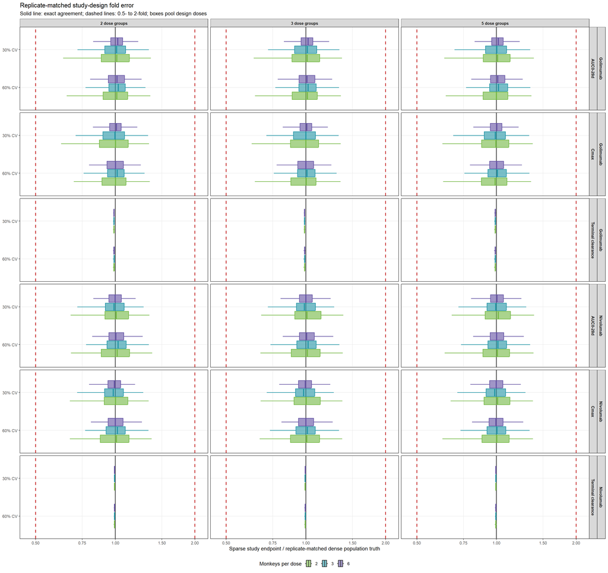

```r
sample_size_colors <- c(
  `2` = "#76B947",
  `3` = "#2596A6",
  `6` = "#6554A4"
)
plot_data <- design_fold_error_replicates |>
  mutate(
    Variability = factor(
      paste0(100 * .data$Variability_CV, "% CV"),
      levels = rev(paste0(100 * settings$variability_cv, "% CV"))
    ),
    Animals = factor(
      .data$N_per_group,
      levels = settings$animals_per_group
    )
  )

fold_error_plot <- ggplot(
  plot_data,
  aes(
    x = .data$Fold_error,
    y = .data$Variability,
    fill = .data$Animals,
    color = .data$Animals
  )
) +
  geom_vline(xintercept = 1, color = "grey30", linewidth = 0.75) +
  geom_vline(
    xintercept = FOLD_LIMITS,
    color = "#C62828",
    linetype = 2,
    linewidth = 0.85
  ) +
  geom_boxplot(
    width = 0.66,
    outlier.shape = NA,
    alpha = 0.62,
    linewidth = 0.6,
    position = position_dodge2(
      width = 0.78,
      padding = 0.10,
      preserve = "single"
    )
  ) +
  scale_x_log10(
    breaks = c(0.5, 0.75, 1, 1.5, 2),
    labels = label_number(accuracy = 0.01)
  ) +
  coord_cartesian(xlim = c(0.47, 2.08), clip = "off") +
  scale_fill_manual(values = sample_size_colors) +
  scale_color_manual(values = sample_size_colors, guide = "none") +
  facet_grid(
    rows = vars(.data$Molecule, .data$Endpoint),
    cols = vars(.data$Design)
  ) +
  labs(
    x = "Sparse study endpoint / replicate-matched dense population truth",
    y = NULL,
    fill = "Monkeys per dose",
    title = "Replicate-matched study-design fold error",
    subtitle = paste(
      "Solid line: exact agreement; dashed lines: 0.5- to 2-fold;",
      "boxes pool design doses"
    )
  ) +
  theme_bw(base_size = 10.5) +
  theme(
    legend.position = "bottom",
    strip.text = element_text(face = "bold"),
    panel.grid.minor = element_blank()
  )

fold_error_plot
```

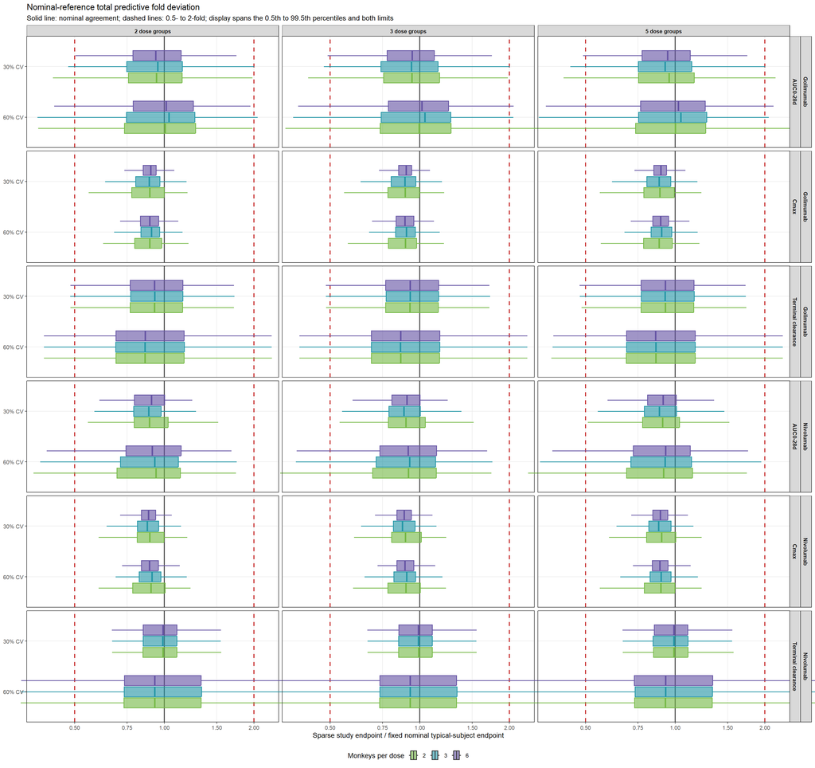

```r
ggsave(
  FOLD_ERROR_FIGURE,
  fold_error_plot,
  width = 17,
  height = 16,
  dpi = 300,
  bg = "white"
)

nominal_plot_data <- nominal_fold_error_replicates |>
  mutate(
    Variability = factor(
      paste0(100 * .data$Variability_CV, "% CV"),
      levels = rev(paste0(100 * settings$variability_cv, "% CV"))
    ),
    Animals = factor(
      .data$N_per_group,
      levels = settings$animals_per_group
    )
  )
nominal_plot_limits <- range(c(
  FOLD_LIMITS,
  quantile(
    nominal_plot_data$Fold_error,
    probs = c(0.005, 0.995),
    names = FALSE
  )
))
nominal_plot_limits <- nominal_plot_limits * c(0.95, 1.05)
nominal_breaks <- c(0.1, 0.2, 0.25, 0.5, 0.75, 1, 1.5, 2, 3, 4, 5, 10)
nominal_breaks <- nominal_breaks[
  nominal_breaks >= nominal_plot_limits[1] &
    nominal_breaks <= nominal_plot_limits[2]
]

nominal_fold_error_plot <- ggplot(
  nominal_plot_data,
  aes(
    x = .data$Fold_error,
    y = .data$Variability,
    fill = .data$Animals,
    color = .data$Animals
  )
) +
  geom_vline(xintercept = 1, color = "grey30", linewidth = 0.75) +
  geom_vline(
    xintercept = FOLD_LIMITS,
    color = "#C62828",
    linetype = 2,
    linewidth = 0.85
  ) +
  geom_boxplot(
    width = 0.66,
    outlier.shape = NA,
    alpha = 0.62,
    linewidth = 0.6,
    position = position_dodge2(
      width = 0.78,
      padding = 0.10,
      preserve = "single"
    )
  ) +
  scale_x_log10(
    breaks = nominal_breaks,
    labels = label_number(accuracy = 0.01)
  ) +
  coord_cartesian(xlim = nominal_plot_limits, clip = "off") +
  scale_fill_manual(values = sample_size_colors) +
  scale_color_manual(values = sample_size_colors, guide = "none") +
  facet_grid(
    rows = vars(.data$Molecule, .data$Endpoint),
    cols = vars(.data$Design)
  ) +
  labs(
    x = "Sparse study endpoint / fixed nominal typical-subject endpoint",
    y = NULL,
    fill = "Monkeys per dose",
    title = "Nominal-reference total predictive fold deviation",
    subtitle = paste(
      "Solid line: nominal agreement; dashed lines: 0.5- to 2-fold;",
      "display spans the 0.5th to 99.5th percentiles and both limits"
    )
  ) +
  theme_bw(base_size = 10.5) +
  theme(
    legend.position = "bottom",
    strip.text = element_text(face = "bold"),
    panel.grid.minor = element_blank()
  )

nominal_fold_error_plot
```

```r
ggsave(
  NOMINAL_FOLD_ERROR_FIGURE,
  nominal_fold_error_plot,
  width = 17,
  height = 16,
  dpi = 300,
  bg = "white"
)
```

# Step 9 Save the consolidated post-processing record

```r
settings_table <- tribble(
  ~Setting, ~Value,
  "Step 1 input MD5", STEP1_INPUT_MD5,
  "Step 2 index MD5", unname(tools::md5sum(STEP2_INDEX_RDS)),
  "Parameter-draw replicates per molecule and CV",
    as.character(settings$n_replicates),
  "Planned dense truth monkeys per replicate and dose",
    as.character(settings$n_population_animals),
  "Observed dense truth monkey counts after exclusions",
    paste(sort(unique(population_truth$Monkeys_in_truth)), collapse = ", "),
  "Step 2 failed profiles excluded", as.character(
    nrow(failed_profile_exclusions)
  ),
  "Matched truth cells with exclusions", as.character(
    nrow(failed_profile_cells)
  ),
  "Failure exclusion scope",
    "matched molecule, CV, replicate, and dose only; other doses retained",
  "Sparse monkeys per dose group",
    paste(settings$animals_per_group, collapse = ", "),
  "Sparse sampling within dose", "without replacement",
  "Monkey reuse across dose groups", "allowed",
  "Primary truth matching",
    "same molecule, CV, parameter replicate, and dose",
  "Secondary reference",
    "fixed dense nominal typical subject by molecule and dose",
  "Sampling seed base", as.character(SAMPLING_SEED_BASE),
  "Force endpoint recalculation", as.character(FORCE_RERUN)
)
write_csv(settings_table, SETTINGS_FILE)

results_record <- list(
  format_version = 3L,
  workflow_stage = "Step 3: post-process results",
  settings = settings_table,
  failed_profile_exclusions = failed_profile_exclusions,
  expected_truth_counts = expected_truth_counts,
  endpoint_checkpoint_inventory = endpoint_checkpoint_inventory,
  individual_endpoints = individual_endpoints,
  population_truth = population_truth,
  nominal_reference_endpoints = nominal_reference_endpoints,
  sampling_assignments = sampling_assignments,
  replicate_fold_error = design_fold_error_replicates,
  fold_error_summary = design_fold_error_summary,
  nominal_fold_error = nominal_fold_error_replicates,
  nominal_fold_error_summary = nominal_fold_error_summary,
  endpoint_success = design_endpoint_success,
  nominal_endpoint_success = nominal_endpoint_success,
  overall_success = overall_design_success,
  analysis_qc = analysis_qc
)
saveRDS(results_record, RESULTS_RDS, compress = "xz")

artifact_paths <- c(
  RESULTS_RDS,
  INDIVIDUAL_ENDPOINT_FILE,
  POPULATION_TRUTH_FILE,
  SAMPLING_ASSIGNMENT_FILE,
  FOLD_ERROR_REPLICATE_FILE,
  FOLD_ERROR_SUMMARY_FILE,
  NOMINAL_REFERENCE_ENDPOINT_FILE,
  NOMINAL_FOLD_ERROR_REPLICATE_FILE,
  NOMINAL_FOLD_ERROR_SUMMARY_FILE,
  ENDPOINT_SUCCESS_FILE,
  OVERALL_SUCCESS_FILE,
  ANALYSIS_QC_FILE,
  FAILED_PROFILE_EXCLUSION_FILE,
  ENDPOINT_CHECKPOINT_INVENTORY_FILE,
  SETTINGS_FILE,
  PACKAGE_FILE,
  FOLD_ERROR_FIGURE,
  NOMINAL_FOLD_ERROR_FIGURE
)
artifact_manifest <- tibble(
  Artifact = basename(artifact_paths),
  Path = normalizePath(artifact_paths, winslash = "/", mustWork = TRUE),
  Bytes = file.info(artifact_paths)$size,
  MD5 = unname(tools::md5sum(artifact_paths))
)
write_csv(artifact_manifest, ARTIFACT_MANIFEST_FILE)

loaded_results <- readRDS(RESULTS_RDS)
if (!identical(loaded_results$analysis_qc, analysis_qc) ||
    !identical(
      loaded_results$failed_profile_exclusions,
      failed_profile_exclusions
    ) ||
    !identical(loaded_results$population_truth, population_truth) ||
    !identical(
      loaded_results$nominal_reference_endpoints,
      nominal_reference_endpoints
    ) ||
    !identical(
      loaded_results$nominal_fold_error_summary,
      nominal_fold_error_summary
    )) {
  stop("The saved Step 3 record failed its round-trip validation.")
}

artifact_manifest |>
  select(.data$Artifact, .data$Bytes, .data$MD5) |>
  kable(caption = "Step 3 artifacts and checksums")
```

Step 3 artifacts and checksums

| Artifact | Bytes | MD5 |
| --- | --- | --- |
| study_design_step3_results.rds | 6130116 | 0d9b6215c2bb96639ea57d0f4d844a1e |
| study_design_individual_dense_sparse_endpoints.csv | 28925777 | e9dc8a577b51504eb094d28e6a221c0e |
| study_design_replicate_matched_dense_truth.csv | 346476 | 85379de5c657457880825d4f6bdb9ca3 |
| study_design_sparse_sampling_assignments.csv | 1591620 | bb64179f04624056fbe409d12a2f48ec |
| study_design_replicate_matched_fold_error.csv | 4441399 | b1c0b82ff69128e864ba65e85ecbc999 |
| study_design_fold_error_summary.csv | 66780 | 24b45fca39efb3c3f3c315919093e071 |
| study_design_nominal_typical_reference_endpoints.csv | 1384 | c5241be353c8c2dc330d14617ffaeef2 |
| study_design_nominal_typical_fold_error.csv | 8271926 | 419007697c4fcc29f883e06cf8f6174c |
| study_design_nominal_typical_fold_error_summary.csv | 67281 | f1ba7cab049aea9d33d0ebb2bc04150d |
| study_design_endpoint_success.csv | 5451 | 426f419cc2e686d6a5a9fc191895ab8f |
| study_design_overall_success.csv | 1478 | 9c1a12211bef2e9c939935f12cef5d21 |
| study_design_analysis_qc.csv | 6614 | d1426554dff03c690b753c140e12b44b |
| study_design_excluded_failed_profiles.csv | 951 | a7eac59d63dbd062523c44a15bbae1d3 |
| study_design_endpoint_checkpoint_inventory.csv | 55016 | 9858c8e3e912af3c0dbbbd99d08bf1e8 |
| study_design_step3_settings.csv | 788 | 1b5b943793fa651cb8d3eec77c3059e2 |
| study_design_step3_software_versions.csv | 123 | 8310a25c5febe059eb0221c7010c5489 |
| study_design_replicate_matched_fold_error.png | 339417 | 2984a709d414eb6584dd55f6bb41b03d |
| study_design_nominal_typical_fold_error.png | 359023 | 543f5ae16659724a13c684e564f2f8f6 |